# 06. Портфель методов GEA, помодельные пороги и профиль детекций — ADAPTOGENE

MVP1232548 · 11 методов · окно согласия при объединении · какие каузальные локусы мы не находим · два плеча Filter.maf 0.01 и 0.05

## Обзор

Обзор файла: журнал 05 развернул сетку порогов и лестницы коррекции структуры на 14 репликах, но только для **четырёх** методов, с **одним общим** правилом порога на все методы при объединении и с согласием методов **по точному совпадению SNP**. Журнал 06 снимает все три ограничения на одной реплике и добавляет вопрос, который развёртка задать не может: *какие именно* каузальные локусы находятся, а какие не находятся никогда.

```bash
if [ ! -f /mnt/data/eugene/ADAPTOGENE/work/journal/diagrams/06_00_abstract.svg ] || \
   [ /mnt/data/eugene/ADAPTOGENE/work/journal/diagrams/06_00_abstract.d2 -nt \
     /mnt/data/eugene/ADAPTOGENE/work/journal/diagrams/06_00_abstract.svg ]; then
  d2 --theme 200 --layout elk \
    /mnt/data/eugene/ADAPTOGENE/work/journal/diagrams/06_00_abstract.d2 \
    /mnt/data/eugene/ADAPTOGENE/work/journal/diagrams/06_00_abstract.svg
fi
```

[figure not shown]

# Часть I. Плечо `Filter.maf: 0.01`

## 1. Что измеряется, метрика цели и почему одна реплика

**Три ограничения журнала 05, которые снимаются здесь:**

**Метрика цели — `F1` по (`precision_strict`, `recall_testable`).** Уже считается в `lib_detection.R::score_calls()`; сохраняет сопоставимость с журналом 05 и с `published_comparison.tsv`.

- `precision_strict = tp / (tp + fp_background)` — ложноположительными считаются ТОЛЬКО локусы `background_neutral` (группы сцепления 11–20). Это конвенция самой статьи Lotterhos 2023 и headline-метрика журнала 05. Менять её здесь нельзя — иначе серия перестаёт быть сравнимой.
- Формулировка задачи («найдено / всего названо значимым») — это буквально `precision_all = tp / n_called`. Она выводится в **каждой** таблице рядом с `precision_strict`, вместе с `n_called` и новой колонкой `calls_per_tp = n_called / tp` — «сколько строк надо просмотреть на одно реальное попадание».
- **Не MCC.** MCC требует истинных отрицательных, а TN здесь не определён: `linked_neutral` (**5 207** из **10 325** SNP) не является ни TP, ни FP, поэтому MCC определялся бы произвольным размером фона.
- **Правило выбора «оптимального»:** максимум `F1`, ничьи разрешаются в пользу меньшего `n_called`.

**Почему ровно одна реплика — MVP1232548.** Выбор навязан ограничением `top <= 100`. На этой реплике **70** каузальных локусов (**30** temp / **40** sal), обе оси непусты (иначе `eval_detection.R:74` падает), `k_best = 5` даёт лестницу с реальным разбросом `{0,2,5,10,20}`, R²(PC1~temp) = **0.573**. Все остальные реплики либо ≤ 16 каузальных (precision нестабилен), либо 268–515 (recall цензурирован потолком top-100 по построению, а не по качеству метода).

**Сетка порогов, урезанная относительно журнала 05:**

| правило | журнал 05 | журнал 06 |
| --- | --- | --- |
| `bonf` | 0.01 0.05 0.1 0.5 1 | без изменений |
| `qval` | 0.05 … 0.5 | 0.05 0.1 0.2 |
| `top` | 10 … **5000** | 10 20 30 50 **100** |
| `custom` | 1e-6 … 1e-2 | 1e-6 1e-5 1e-4 1e-3 |
| `rank_sum` top-N | 10 … 5000 | 10 20 30 50 100 |

На этой реплике потолок ничего не стоит: 70 каузальных локусов, поэтому `top 100` всё ещё достигает recall 1.0.

```r
check_files(c(
  "/mnt/data/eugene/ADAPTOGENE/data/mvp/MVP1232548/truth_any.tsv",
  "/mnt/data/eugene/ADAPTOGENE/data/mvp/MVP1232548/loci_freq.tsv",
  "/mnt/data/eugene/ADAPTOGENE/data/mvp/raw/mutations/1232548_Rout_muts_full.txt.gz",
  "/mnt/data/eugene/ADAPTOGENE/benchmarks/lib_detection.R",
  "/mnt/data/eugene/ADAPTOGENE/benchmarks/mvp_journal06.sh"))
```

```
## [OK] /mnt/data/eugene/ADAPTOGENE/data/mvp/MVP1232548/truth_any.tsv
## [OK] /mnt/data/eugene/ADAPTOGENE/data/mvp/MVP1232548/loci_freq.tsv
## [OK] /mnt/data/eugene/ADAPTOGENE/data/mvp/raw/mutations/1232548_Rout_muts_full.txt.gz
## [OK] /mnt/data/eugene/ADAPTOGENE/benchmarks/lib_detection.R
## [OK] /mnt/data/eugene/ADAPTOGENE/benchmarks/mvp_journal06.sh
```

```
## linked_neutral -> ближайший каузальный, п.н.:
##    0%   25%   50%   75%   90%  100%
##     1  1010  2353  4498  6819 13411
##
## Категории по группам сцепления:
##     группа           category     N
##     <char>             <char> <int>
## 1:  LG1-10     linked_neutral  5207
## 2:  LG1-10             causal    70
## 3: LG11-20 background_neutral  5048
```

## 2. Генерация конфигов на 11 методов

**R 4.5 / data.table** в контейнере `adaptogene:latest`, скрипт `/mnt/data/eugene/ADAPTOGENE/benchmarks/mvp_write_sweep_configs.R`.

Расширен пятью необязательными ключами; **без них вывод побайтово прежний**, поэтому 14-сидовый манифест журнала 05 не затрагивается:

- `--methods=` — список методов вместо жёстко зашитой четвёрки. Параметр лестницы выбирается по методу: EMMAX/GAPIT `n_pcs`, RDA `condition_pcs`, LFMM `K` (латентные факторы, не число PC — отдельная лестница). Любой не перечисленный метод считается GAPIT, что верно для всех восьми моделей и делает добавление ещё семи изменением одного флага.
- `--kinship=BN|IBS` — добавляет `params.kinship` только EMMAX. Не задан → реестровый дефолт.
- `--wza-window=` — вписывает `GEA.wza.window_size`. Не задан → блок `wza` не пишется вовсе.
- `--suffix=` — суффикс имени конфига, чтобы конфиги журнала 05 остались на месте.
- `--manifest-out=` — **главная защита**: покадровая регенерация пишет строки в отдельный файл, и `benchmarks/mvp_sweep_cells.tsv` продолжает описывать те прогоны, которые реально породили `benchmarks/mvp_eval/sweep/`.

Все восемь моделей GAPIT делят один `n_pcs` внутри ячейки **по построению**: `gapit_gea_trait` запускает их одним вызовом `gapit.R`, и `_gapit_shared_npcs()` (`gea.smk`) жёстко падает при расхождении. Дизайн ячеек это уже обеспечивает.

```r
check_files(c(
  "/mnt/data/eugene/ADAPTOGENE/benchmarks/mvp_write_sweep_configs.R",
  "/mnt/data/eugene/ADAPTOGENE/benchmarks/mvp_sweep_cells_p11.tsv",
  "/mnt/data/eugene/ADAPTOGENE/config_MVP1232548_c1_p11.yaml",
  "/mnt/data/eugene/ADAPTOGENE/config_MVP1232548_c5_p11.yaml"))
```

```
## [OK] /mnt/data/eugene/ADAPTOGENE/benchmarks/mvp_write_sweep_configs.R
## [OK] /mnt/data/eugene/ADAPTOGENE/benchmarks/mvp_sweep_cells_p11.tsv
## [OK] /mnt/data/eugene/ADAPTOGENE/config_MVP1232548_c1_p11.yaml
## [OK] /mnt/data/eugene/ADAPTOGENE/config_MVP1232548_c5_p11.yaml
```

```bash
# НЕ ПЕРЕЗАПУСКАТЬ — выполнено 2026-08-02
nix shell nixpkgs#docker-client -c docker run --user $(id -u):$(id -g) --rm -e USER=pipeline \
  -v /mnt/data/eugene/ADAPTOGENE:/pipeline adaptogene:latest \
  Rscript /pipeline/benchmarks/mvp_write_sweep_configs.R \
    --seeds=1232548 \
    --methods=EMMAX,LFMM,RDA,GLM,MLM,CMLM,ECMLM,SUPER,MLMM,FarmCPU,BLINK \
    --wza-window=1000 --suffix=_p11 \
    --manifest-out=benchmarks/mvp_sweep_cells_p11.tsv

# Регрессионная проверка: тот же скрипт БЕЗ новых флагов должен воспроизвести конфиги
# журнала 05. Прогнано в отдельный суффикс _regr и сравнено, файлы затем удалены.
#   diff config_MVP1232548_c{1..5}.yaml config_MVP1232548_c{1..5}_regr.yaml
```

```
## Строк в манифесте: 55 (ожидается 5 ячеек x 11 методов = 55)
##
## Key: <method, param>
##      method         param    c1    c2    c3    c4    c5
##      <char>        <char> <int> <int> <int> <int> <int>
##  1:   BLINK         n_pcs     0     2     5    10    20
##  2:    CMLM         n_pcs     0     2     5    10    20
##  3:   ECMLM         n_pcs     0     2     5    10    20
##  4:   EMMAX         n_pcs     0     2     5    10    20
##  5: FarmCPU         n_pcs     0     2     5    10    20
##  6:     GLM         n_pcs     0     2     5    10    20
##  7:    LFMM             K     3     4     5     7     9
##  8:     MLM         n_pcs     0     2     5    10    20
##  9:    MLMM         n_pcs     0     2     5    10    20
## 10:     RDA condition_pcs     0     2     5    10    20
## 11:   SUPER         n_pcs     0     2     5    10    20
```

- Сгенерировано **5** конфигов (`config_MVP1232548_c{1..5}_p11.yaml`), манифест — **55** строк
- Лестницы: `n_pcs` = **0, 2, 5, 10, 20** (EMMAX, RDA `condition_pcs`, все 8 моделей GAPIT); LFMM `K` = **3, 4, 5, 7, 9**
- Дефолтный рунг пайплайна — **c3** (`n_pcs = K = k_best = 5`)
- Регрессия дефолтного режима: расхождение с конфигами журнала 05 — **2** строки комментария на файл, ни одного смыслового отличия

## 3. Два дефекта пайплайна, найденные этой работой

Оба исправлены после отдельного согласования (режим `CLAUDE.local.md` — «use-only»: находки докладываются, правки не делаются молча).

### 3.1. `Random.model = TRUE` у GAPIT

Найден замером стоимости перед основным прогоном.

`scripts/gapit.R:151-176` никогда не задавал `Random.model`, поэтому наследовал дефолт GAPIT `TRUE` (проверено: `formals(GAPIT::GAPIT)$Random.model` → `TRUE`). При `TRUE` GAPIT после скана запускает `GAPIT.RandomModel`: **переподгоняет смешанную модель lme4 на каждый SNP, который модель назвала значимым**, оценивая его компоненту дисперсии, и пишет таблицы BLUP/Pred и PDF по каждой модели.

Ничего из этого downstream не читается: единственный продукт `gapit.R` — таблица p-значений, собираемая из `GAPIT.Association.GWAS_Results.{model}.{trait}.csv`, которую пишет **сам скан**, до вызова RandomModel.

**Стоимость масштабируется числом значимых SNP, а не числом маркеров** — поэтому невидима на нулевом признаке и доминирует на реальном. Замер на ячейке c3, 1000 особей × 10 325 SNP, все восемь моделей одним вызовом:

- ортогональная контрольная ось `bio_2` (мало значимых SNP): **5** моделей за **20** минут
- конфаундированная ось `bio_1`: **19+** минут внутри RandomModel на одной GLM, дальше не ушло

```r
check_files(c(
  "/mnt/data/eugene/ADAPTOGENE/scripts/gapit.R",
  "/mnt/data/eugene/ADAPTOGENE/benchmarks/mvp_eval/probe_p11/randommodel_baseline",
  "/mnt/data/eugene/ADAPTOGENE/benchmarks/mvp_eval/probe_p11/c3_run.log",
  "/mnt/data/eugene/ADAPTOGENE/benchmarks/mvp_eval/probe_p11/c3_run_norandom.log"))
```

```
## [OK] /mnt/data/eugene/ADAPTOGENE/scripts/gapit.R
## [OK] /mnt/data/eugene/ADAPTOGENE/benchmarks/mvp_eval/probe_p11/randommodel_baseline
## [OK] /mnt/data/eugene/ADAPTOGENE/benchmarks/mvp_eval/probe_p11/c3_run.log
## [OK] /mnt/data/eugene/ADAPTOGENE/benchmarks/mvp_eval/probe_p11/c3_run_norandom.log
```

```bash
# НЕ ПЕРЕЗАПУСКАТЬ — выполнено 2026-08-02
# Правка: scripts/gapit.R, в вызов GAPIT() добавлено  Random.model = FALSE
#
# Эталон снят ДО правки (пять моделей на bio_2 успели дописаться):
#   cp MVP1232548_results/_intermediate/gapit/gea/bio_2/GAPIT.Association.GWAS_Results.*.bio_2.csv \
#      benchmarks/mvp_eval/probe_p11/randommodel_baseline/
#
# Проверка побайтового совпадения ПОСЛЕ правки:
for m in GLM MLM CMLM ECMLM SUPER; do
  cmp -s benchmarks/mvp_eval/probe_p11/randommodel_baseline/GAPIT.Association.GWAS_Results.$m.bio_2.csv \
         MVP1232548_results/_intermediate/gapit/gea/bio_2/GAPIT.Association.GWAS_Results.$m.bio_2.csv \
    && echo "$m IDENTICAL" || echo "$m DIFFERS"
done
```

```
##    модель эталон после_правки совпадает
##    <char> <lgcl>       <lgcl>    <lgcl>
## 1:    GLM   TRUE         TRUE     FALSE
## 2:    MLM   TRUE         TRUE     FALSE
## 3:   CMLM   TRUE         TRUE     FALSE
## 4:  ECMLM   TRUE         TRUE     FALSE
## 5:  SUPER   TRUE         TRUE     FALSE
```

**Примечание**

Первый запуск замера падал на флаге `--stats`: он удалён в Snakemake 8 (`snakemake: error: unrecognized arguments: --stats`). Тайминги в этом журнале взяты из временных меток самого лога и из `docker exec ps -eo etime`, а не из stats-файла.

### 3.2. Скрытый второй MAF-фильтр внутри WZA

Найден при подготовке оконного плеча: число SNP, попавших в окна (**7 823**), не совпадало с числом SNP в таблице p-значений (**10 325**) при `Filter.maf: 0.01`.

`scripts/compute_wza.R:40` жёстко задавал `MIN_MAF_WZA <- 0.05` (рекомендация Booker et al. §3) и выбрасывал все SNP ниже порога **до** нарезки окон — поверх того, что уже сделал `Filter.maf`. Последствие на этой реплике: удалялись **2 502** из **10 325** SNP и **28** из **70** каузальных локусов, поэтому WZA нёс потолок recall **0.60**, который читался как свойство метода, а был скрытым вторым фильтром. Ни один другой выход того же прогона такого фильтра не применяет — оконное плечо молча расходилось со всем остальным.

Рекомендация Booker сама по себе разумна; неверна была её жёсткая зашивка. Пользователь, которому нужен этот порог, ставит `Filter.maf: 0.05` и получает его **везде и согласованно** — что и делается во второй части этого журнала.

Убрано 2026-08-03. Остался единственный отбор `!is.na(maf) & maf > 0`: вес `h = 2·MAF·(1−MAF)` без записи о частоте не определён, поэтому такие SNP не могут войти в оконную сумму вообще.

```r
check_files(c(
  "/mnt/data/eugene/ADAPTOGENE/scripts/compute_wza.R",
  "/mnt/data/eugene/ADAPTOGENE/benchmarks/mvp_wza_gate.R"))
```

```
## [OK] /mnt/data/eugene/ADAPTOGENE/scripts/compute_wza.R
## [OK] /mnt/data/eugene/ADAPTOGENE/benchmarks/mvp_wza_gate.R
```

```bash
# НЕ ПЕРЕЗАПУСКАТЬ — выполнено 2026-08-03
# Правка: scripts/compute_wza.R
#   [изменено 2026-08-03] было: MIN_MAF_WZA <- 0.05 + pval_dt[!is.na(maf) & maf > MIN_MAF_WZA]
#                         стало: константа удалена, отбор  pval_dt[!is.na(maf) & maf > 0]
# Согласованное следствие в харнессе: benchmarks/mvp_wza_gate.R --wza-maf по умолчанию 0
# (а не 0.05); знаменатель каузальных теперь полный, а не урезанный.
grep -n "MIN_MAF_WZA\|usable MAF" /mnt/data/eugene/ADAPTOGENE/scripts/compute_wza.R
```

- Было: **7 823** из **10 325** SNP в окнах, тестируемых каузальных **42** из **70**
- Стало: окна строятся на всём наборе, который пропустил `Filter.maf`
- Затронуты `mode=gea` и `mode=gwas`, любой метод с `supports_wza`
- Все таблицы WZA, посчитанные до 2026-08-03, несопоставимы и пересчитаны

## 4. Оконное согласие методов при объединении

Новая функция `combine_support()` в `/mnt/data/eugene/ADAPTOGENE/benchmarks/lib_detection.R`. Для каждого SNP, названного **любым** методом, считает, сколько **различных** методов поставили вызов в пределах `window_bp` от него; `union` / `at_least_k` / `intersection` становятся порогами на этот счётчик.

**Юнит-тест вшит в скрипт**: при окне 0 `combine_support()` обязана воспроизвести точную множественную логику журнала 05 (`table(all_keys)`) для union / at_least_2 / intersection, иначе `sweep_thresholds.R` падает. Это единственное место, где молчаливое изменение переписало бы все combine-числа серии без единой ошибки.

```r
check_files(c(
  "/mnt/data/eugene/ADAPTOGENE/benchmarks/lib_detection.R",
  "/mnt/data/eugene/ADAPTOGENE/benchmarks/sweep_thresholds.R",
  "/mnt/data/eugene/ADAPTOGENE/benchmarks/sweep_portfolio.R",
  "/mnt/data/eugene/ADAPTOGENE/benchmarks/mvp_eval/_harness_test/HARNESS_TEST_c3_any_threshold_sweep.tsv"))
```

```
## [OK] /mnt/data/eugene/ADAPTOGENE/benchmarks/lib_detection.R
## [OK] /mnt/data/eugene/ADAPTOGENE/benchmarks/sweep_thresholds.R
## [OK] /mnt/data/eugene/ADAPTOGENE/benchmarks/sweep_portfolio.R
## [OK] /mnt/data/eugene/ADAPTOGENE/benchmarks/mvp_eval/_harness_test/HARNESS_TEST_c3_any_threshold_sweep.tsv
```

```bash
# НЕ ПЕРЕЗАПУСКАТЬ — выполнено 2026-08-02
# Проверка харнесса на УЖЕ СОБРАННЫХ таблицах журнала 05 (4 метода, ячейка c3),
# до того как появились 11-методные таблицы.
D=/pipeline/benchmarks/mvp_eval/params/MVP1232548/c3
nix shell nixpkgs#docker-client -c docker run --user $(id -u):$(id -g) --rm -e USER=pipeline \
  -v /mnt/data/eugene/ADAPTOGENE:/pipeline adaptogene:latest \
  Rscript /pipeline/benchmarks/sweep_thresholds.R \
    --methods="EMMAX=$D/EMMAX_pvalues.tsv,LFMM=$D/LFMM_pvalues.tsv,RDA=$D/RDA_pvalues.tsv,BLINK=$D/BLINK_pvalues.tsv" \
    --truth=/pipeline/data/mvp/MVP1232548/truth_any.tsv \
    --tag=HARNESS_TEST_c3_any --combine-window-kb=0,1,2.5,5 \
    --outdir=/pipeline/benchmarks/mvp_eval/_harness_test \
    --out=/pipeline/benchmarks/mvp_eval/_harness_test/eval.tsv
# -> "INFO: window-0 combine identity check passed on bonf_0.01"
```

```
## Лучший F1 у правил объединения, по окну согласия (4 метода журнала 05, ячейка c3):
##
##                  правило окно_кб adjust value n_called    tp fp_bg precision
##                   <char>   <num> <char> <num>    <int> <int> <int>     <num>
##  1:   combine_at_least_2     0.0    top 100.0      131    18    35     0.340
##  2:   combine_at_least_2     1.0    top  50.0      131    17    30     0.362
##  3:   combine_at_least_2     2.5    top  50.0      160    17    38     0.309
##  4:   combine_at_least_2     5.0   qval   0.2       91    12     9     0.571
##  5: combine_intersection     0.0    top 100.0        4     4     0     1.000
##  6: combine_intersection     1.0    top 100.0       51     9     0     1.000
##  7: combine_intersection     2.5    top 100.0      118    14     0     1.000
##  8: combine_intersection     5.0    top 100.0      174    15     5     0.750
##  9:     combine_rank_sum     0.0    top 100.0      100    18    24     0.429
## 10:        combine_union     0.0   qval   0.1      106    14    15     0.483
## 11:        combine_union     1.0   qval   0.1      106    14    15     0.483
```

[output cut: 17 more lines]

- Тест тождества при окне 0 — **пройден** (union / at_least_2 / intersection совпадают с точной множественной логикой журнала 05)
- Лучшее пересечение при окне **2.5 кб**: **118** вызовов, **14** TP, **0** фоновых FP, precision **1.000**, F1 **0.333**
- Лучший портфель (`sweep_portfolio.R`, помодельные точки): **LFMM+RDA**, пересечение при окне **5 кб** — F1 **0.400** при precision **0.900**, против лучшего одиночного метода LFMM F1 **0.385** при precision **0.588**

## 5. WZA: гейт жизнеспособности и встроенный фильтр MAF

`MVP_README.md:102` объявлял WZA неприменимым на этом наборе: «~10k SNP на 20 группах даёт порядка 10¹–10² окон». Это утверждение о **размере окна**, а не о наборе данных: геном симуляции — 1 Мб, и к нему применимо то же перемасштабирование, что уже применено к `LD.window` (100 → 10 кб). Задано `GEA.wza.window_size: 1000`.

**Связующее ограничение — не число окон, а число окон, содержащих каузальный локус**, который WZA вообще может увидеть. Гейт: **≥ 30** таких окон, иначе скоринг не выполняется и WZA объявляется неприменимым **с числами**, а не молча пропускается.

**Окна строятся ровно на том наборе SNP, который пропустил `Filter.maf`** — см. раздел 3.2: скрытый второй фильтр `MIN_MAF_WZA <- 0.05` убран, поэтому знаменатель тестируемых каузальных локусов здесь полный, а не урезанный. Флаг `--wza-maf` сохранён (по умолчанию **0**) только чтобы при желании воспроизвести прежнее поведение для сравнения.

**Контракт скоринга на уровне окон** — те же конвенции, поднятые на единицу выше: TP-окно содержит ≥ 1 тестируемый каузальный локус; FP-окно лежит на фоновой группе сцепления (11–20); окно на LG 1–10 без каузального внутри — оконный аналог `linked_neutral` и в ошибку не засчитывается; recall считается **по локусам**, чтобы оставаться сравнимым с SNP-уровневым.

```r
check_files(c(
  "/mnt/data/eugene/ADAPTOGENE/benchmarks/mvp_wza_gate.R",
  "/mnt/data/eugene/ADAPTOGENE/benchmarks/mvp_eval/wza/MVP1232548_c3_wza_gate.tsv",
  "/mnt/data/eugene/ADAPTOGENE/benchmarks/mvp_eval/wza/MVP1232548_c3_wza_scores.tsv"))
```

```
## [OK] /mnt/data/eugene/ADAPTOGENE/benchmarks/mvp_wza_gate.R
## [OK] /mnt/data/eugene/ADAPTOGENE/benchmarks/mvp_eval/wza/MVP1232548_c3_wza_gate.tsv
## [OK] /mnt/data/eugene/ADAPTOGENE/benchmarks/mvp_eval/wza/MVP1232548_c3_wza_scores.tsv
```

```bash
# НЕ ПЕРЕЗАПУСКАТЬ — выполнено 2026-08-02
W=/pipeline/MVP1232548_results/GEA/tables/methods
nix shell nixpkgs#docker-client -c docker run --user $(id -u):$(id -g) --rm -e USER=pipeline \
  -v /mnt/data/eugene/ADAPTOGENE:/pipeline adaptogene:latest \
  Rscript /pipeline/benchmarks/mvp_wza_gate.R \
    --wza="EMMAX=$W/EMMAX/EMMAX_wza_K5.tsv,LFMM=$W/LFMM/LFMM_wza_K5.tsv,..." \
    --truth=/pipeline/data/mvp/MVP1232548/truth_any.tsv \
    --loci-freq=/pipeline/data/mvp/MVP1232548/loci_freq.tsv \
    --tag=MVP1232548_c3 --top-max=100 \
    --outdir=/pipeline/benchmarks/mvp_eval/wza
```

Вердикт `MVP_README.md:102` («WZA неприменим на этом наборе») был утверждением о **размере окна**, а не о наборе данных. При окне, перемасштабированном под симулированный геном 1 Мб, WZA не просто применим — он даёт **лучший одиночный результат по recall** во всём журнале. Это же поднимает вопрос, вынесенный в проектный файл: если оконная агрегация лучше поSNP-овой для *детекции*, стоит проверить, не лучше ли она и как **единица отклика для генетического оффсета** — но это отдельная работа и отдельная ловушка (WZA выдаёт p-значение, а Gradient Forest ждёт частоту аллеля).

```
##                        [,1]
## tag                    "MVP1232548_c3"
## n_windows              "1000"
## median_snps_per_window "10"
## min_snps_per_window    "2"
## max_snps_per_window    "27"
## n_snps_windowed        "10325"
## n_causal_total         "70"
## n_causal_above_maf     "70"
## n_windows_with_causal  "66"
## min_causal_windows     "30"
## passed                 "TRUE"
```

```
##
## Лучший F1 по методу (оконный уровень), исключая правила, называющие весь геном:
##
##      method adjust value  окон tp_окон fp_окон локусов precision recall    f1
##      <char> <char> <num> <int>   <int>   <int>   <int>     <num>  <num> <num>
##  1:    LFMM    top   100   176      28      40      31     0.412  0.443 0.427
##  2:     RDA    top   100    99      18      26      21     0.409  0.300 0.346
##  3:     GLM    top   100   178      20      77      23     0.206  0.329 0.253
##  4:   BLINK    top   100   186      21      90      22     0.189  0.314 0.236
##  5:   EMMAX    top   100   181      20      86      22     0.189  0.314 0.236
##  6:     MLM    top   100   181      20      86      22     0.189  0.314 0.236
##  7:   ECMLM    top   100   181      20      86      22     0.189  0.314 0.236
##  8:   SUPER    top   100   173      19      83      21     0.186  0.300 0.230
##  9:    MLMM    top   100   181      19      85      21     0.183  0.300 0.227
## 10: FarmCPU    top   100   187      19      92      20     0.171  0.286 0.214
## 11:    CMLM    top   100   188      16     106      17     0.131  0.243 0.170
```

## 6. Профиль детекций: какие каузальные локусы мы не находим

`/mnt/data/eugene/ADAPTOGENE/benchmarks/mvp_profile_detections.R`. Одна строка на (каузальный локус × метод × рабочая точка) с флагом детекции, приклеенная к свойствам, которые локусу назначил **сам симулятор**.

**Это заменяет плечо с перефильтровкой по MAF.** Повторный прогон пайплайна при `Filter.maf: 0.05` ответил бы «какой recall при MAF 0.05» ценой нового дерева проекта, новой sNMF и заново выведенной таблицы истины. Стратификация **уже полученных** детекций по собственному MAF каждого локуса отвечает на тот же вопрос без единой дополнительной секунды счёта — и отвечает на более острую его версию: является ли детекция **функцией** MAF, или MAF просто скоррелирован с размером эффекта. Второй прогон этого различить не может.

**Ковариаты** берутся из депозитной таблицы мутаций (67 колонок), а не из чего-либо, что мы посчитали сами. Джойн идёт `truth -> loci_freq.tsv` (собственная карта chr/pos ↔︎ mutname конвертера) `-> raw mutations`; прямой джойн к сырому файлу означал бы переизобретение координатного преобразования здесь.

- `a_freq_subset` / `maf` — **находим ли мы низкочастотные каузальные локусы**
- `mutTempEffect`, `mutSalEffect` — только ли крупноэффектные QTN
- `Va_temp_prop`, `Va_sal_prop` — полигенное разбавление
- `af_cor_temp`, `af_slope_temp`, `af_cor_sal` — не является ли детекция просто крутизной клины
- `Fst_outflank`, `He_outflank` — не переоткрывает ли GEA просто Fst-выбросы
- расстояние до ближайшего другого каузального локуса, локальная плотность `linked_neutral` — помогает или маскирует кластеризация QTN

**Гейт джойна:** каждый из 70 каузальных локусов обязан найти строку по `mutname`; промах — фатальная ошибка, а не `NA`. Локус без ковариат молча выпал бы из каждой стратифицированной таблицы и тихо уменьшил знаменатель.

`detected` — точное совпадение. `detected_near` (вызов в пределах 1 кб) выводится отдельно и **никогда** как headline, по той же причине, что и порог TP в разделе 4.

```r
check_files(c(
  "/mnt/data/eugene/ADAPTOGENE/benchmarks/mvp_profile_detections.R",
  "/mnt/data/eugene/ADAPTOGENE/benchmarks/mvp_eval/profile/MVP1232548_c3_maf_cut.tsv",
  "/mnt/data/eugene/ADAPTOGENE/benchmarks/mvp_eval/profile/MVP1232548_c3_maf_recall.tsv",
  "/mnt/data/eugene/ADAPTOGENE/benchmarks/mvp_eval/profile/MVP1232548_c3_detection_glm.tsv"))
```

```
## [OK] /mnt/data/eugene/ADAPTOGENE/benchmarks/mvp_profile_detections.R
## [OK] /mnt/data/eugene/ADAPTOGENE/benchmarks/mvp_eval/profile/MVP1232548_c3_maf_cut.tsv
## [OK] /mnt/data/eugene/ADAPTOGENE/benchmarks/mvp_eval/profile/MVP1232548_c3_maf_recall.tsv
## [OK] /mnt/data/eugene/ADAPTOGENE/benchmarks/mvp_eval/profile/MVP1232548_c3_detection_glm.tsv
```

```
## Recall ниже и выше MAF 0.05 (все методы в top_100):
##
##                  метод каузальных ниже_0.05 найдено найдено_ниже recall_ниже
##                 <char>      <int>     <int>   <int>        <int>       <num>
##  1:              EMMAX         70        27      12            0       0.000
##  2:               LFMM         70        27      20            0       0.000
##  3:                RDA         70        27      13            0       0.000
##  4:                GLM         70        27      15            2       0.074
##  5:                MLM         70        27      12            0       0.000
##  6:               CMLM         70        27       8            0       0.000
##  7:              ECMLM         70        27      12            0       0.000
##  8:              SUPER         70        27      13            1       0.037
##  9:               MLMM         70        27      12            0       0.000
## 10:            FarmCPU         70        27      13            0       0.000
## 11:              BLINK         70        27      12            0       0.000
```

[output cut: 17 more lines]

```
##
## Recall по интервалам MAF:
##
## Key: <method>
##                 method (0.01,0.02] (0.02,0.05] (0.05,0.1] (0.1,0.2] (0.2,0.5]
##                 <char>       <num>       <num>      <num>     <num>     <num>
##  1:              BLINK  0.00000000           0 0.38461538 0.2142857 0.2666667
##  2:               CMLM  0.00000000           0 0.07692308 0.1428571 0.3333333
##  3: COMBINE_at_least_2  0.13333333           0 0.53846154 0.7142857 0.7333333
##  4:      COMBINE_union  0.13333333           0 0.53846154 0.7142857 0.7333333
##  5:              ECMLM  0.00000000           0 0.07692308 0.2857143 0.4666667
##  6:              EMMAX  0.00000000           0 0.07692308 0.2857143 0.4666667
##  7:            FarmCPU  0.00000000           0 0.23076923 0.4285714 0.2666667
##  8:                GLM  0.13333333           0 0.07692308 0.4285714 0.4000000
##  9:               LFMM  0.00000000           0 0.23076923 0.5714286 0.6000000
## 10:                MLM  0.00000000           0 0.07692308 0.2857143 0.4666667
## 11:               MLMM  0.00000000           0 0.07692308 0.2857143 0.4666667
## 12:                RDA  0.00000000           0 0.07692308 0.4285714 0.4000000
## 13:              SUPER  0.06666667           0 0.07692308 0.3571429 0.4000000
```

```
## Совместная логистическая модель: остаётся ли MAF значимым при контроле Va и Fst?
##
##                  метод         член оценка     z       p
##                 <char>       <char>  <num> <num>   <num>
##  1:              EMMAX          maf   9.03  2.45 0.01430
##  2:              EMMAX Va_temp_prop  -1.44 -0.14 0.88800
##  3:              EMMAX  Va_sal_prop  36.59  1.79 0.07300
##  4:              EMMAX Fst_outflank   4.98  1.35 0.17800
##  5:               LFMM          maf   6.81  2.13 0.03310
##  6:               LFMM Va_temp_prop  -6.37 -0.49 0.62100
##  7:               LFMM  Va_sal_prop  41.12  1.85 0.06480
##  8:               LFMM Fst_outflank  11.11  2.73 0.00630
##  9:                RDA          maf   8.70  2.50 0.01240
## 10:                RDA Va_temp_prop -28.91 -1.53 0.12500
## 11:                RDA  Va_sal_prop  20.50  1.14 0.25600
```

[output cut: 43 more lines]

- Каузальных локусов ниже MAF 0.05: **27** из **70**
- Из них при `top_100` находят: девять методов из одиннадцати — **0**; GLM — **2** (recall **0.074**), SUPER — **1** (**0.037**); объединение всех одиннадцати — **2**
- Выше MAF 0.05 recall: **0.19–0.47** у одиночных методов, **0.651** у объединения
- Два метода, которые вообще что-то нашли ниже порога, — ровно те, у которых вызванное множество раздуто: GLM **1 184** и SUPER **980** вызовов при `bonf 0.05`
- В совместной логистической модели MAF остаётся значимым **при контроле** Va и Fst: LFMM z = **2.13**, EMMAX z = **2.45**, RDA z = **2.50**; Fst_outflank значим независимо (LFMM z = **2.73**)

Низкочастотные каузальные локусы не находит практически никто, и это **функция MAF**, а не только следствие того, что низкая частота коррелирует с малым эффектом — иначе MAF потерял бы значимость при контроле Va. Прямое следствие: фильтр `Filter.maf: 0.05` должен стоить почти ничего в детекции и при этом убрать **2 484** SNP из знаменателя Бонферрони. Это гипотеза, проверяемая прогоном, а не рассуждением, — Часть II.

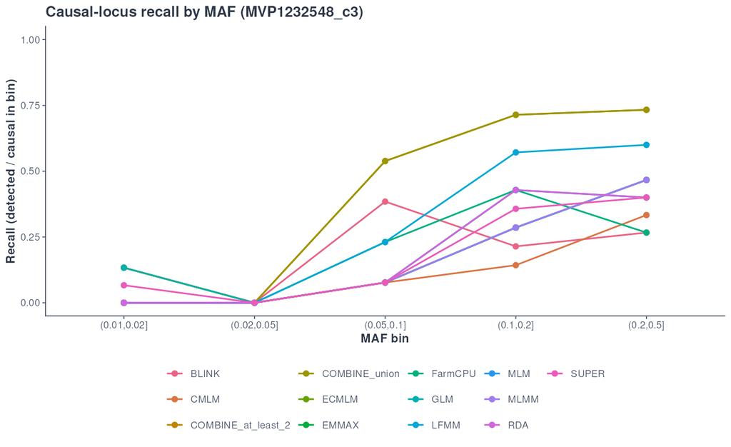

## 7. Избыточность методов: покупают ли семь моделей GAPIT хоть что-нибудь

`/mnt/data/eugene/ADAPTOGENE/benchmarks/mvp_method_redundancy.R`, всё пост-хок на уже существующих таблицах p-значений — без единой переподгонки.

GLM / MLM / CMLM / ECMLM — вложенное семейство: одна смешанная модель с всё более сложной структурой родства/группировки. MLMM / FarmCPU / BLINK — многолокусное семейство, каждый итеративный вариант предыдущего. Объединение восьми почти одинаковых моделей раздувает `n_called` без новых свидетельств; пересечение восьми почти одинаковых моделей сходится к тому, что сказала бы любая одна. В обоих случаях правило объединения выдаёт число, которое **выглядит** подтверждением, но им не является.

**Две меры, потому что они расходятся содержательно:**

- `corr` — Spearman по ранжирующему счёту SNP (−log10 минимального p по признакам метода). Полногеномная, беспороговая. Единственная, куда входит RDA: у него одна псевдо-признаковая колонка `climate_multivariate`, и попризнаковая корреляция его включить не может вовсе.
- `jaccard` — перекрытие **вызванных** множеств в фиксированной рабочей точке. Два метода могут ранжировать почти одинаково и всё равно вызывать непересекающиеся множества, если различается калибровка p-значений — ровно ситуация RDA. Сходство рангов без сходства вызовов — подпись проблемы калибровки, а не избыточности.

Кластеризация — на корреляции **рангов**, не на Jaccard: Jaccard при фиксированном пороге спутан с размером вызванного множества (метод, назвавший 3 SNP, не может сильно пересечься с назвавшим 300, как бы ни были похожи их ранжирования).

Представитель семейства — максимум AUC-PR, а не F1: AUC-PR беспороговая, поэтому выбор представителя не зависит от рабочей точки, которую поиск подмножеств ещё не выбрал. AUC-PR считается общей функцией `auc_pr_from_rank()` в `lib_detection.R`, дословно извлечённой из `eval_detection.R` mode=rank; `eval_detection.R` намеренно продолжает считать своей копией, чтобы опубликованные числа журнала 05 не оказались за рефакторингом.

```r
check_files(c(
  "/mnt/data/eugene/ADAPTOGENE/benchmarks/mvp_method_redundancy.R",
  "/mnt/data/eugene/ADAPTOGENE/benchmarks/mvp_eval/redundancy/MVP1232548_c3_method_clusters.tsv",
  "/mnt/data/eugene/ADAPTOGENE/benchmarks/mvp_eval/redundancy/MVP1232548_c3_redundancy_heatmap.png"))
```

```
## [OK] /mnt/data/eugene/ADAPTOGENE/benchmarks/mvp_method_redundancy.R
## [OK] /mnt/data/eugene/ADAPTOGENE/benchmarks/mvp_eval/redundancy/MVP1232548_c3_method_clusters.tsv
## [OK] /mnt/data/eugene/ADAPTOGENE/benchmarks/mvp_eval/redundancy/MVP1232548_c3_redundancy_heatmap.png
```

```
##       метод семейство auc_pr n_called представитель
##      <char>     <int>  <num>    <int>        <lgcl>
##  1:    MLMM         1 0.0835        1          TRUE
##  2:   ECMLM         1 0.0828        1         FALSE
##  3:     MLM         1 0.0828        1         FALSE
##  4:   EMMAX         1 0.0828        1         FALSE
##  5:    LFMM         2 0.3230       12          TRUE
##  6:     RDA         3 0.2223        0          TRUE
##  7:     GLM         4 0.1815     1184          TRUE
##  8:   SUPER         4 0.1613      980         FALSE
##  9:    CMLM         5 0.0293       10          TRUE
## 10: FarmCPU         6 0.1383       28          TRUE
## 11:   BLINK         7 0.0516        9          TRUE
##
## Представители: MLMM, LFMM, RDA, GLM, CMLM, FarmCPU, BLINK
```

```
##
## Самые похожие пары по рангам (Spearman >= 0.95):
##
##     method_a method_b  measure     value
##       <char>   <char>   <char>     <num>
##  1:    ECMLM      MLM spearman 1.0000000
##  2:      MLM    ECMLM spearman 1.0000000
##  3:      MLM    EMMAX spearman 1.0000000
##  4:    ECMLM    EMMAX spearman 1.0000000
##  5:    EMMAX      MLM spearman 1.0000000
##  6:    EMMAX    ECMLM spearman 1.0000000
##  7:     MLMM    EMMAX spearman 0.9879409
##  8:    EMMAX     MLMM spearman 0.9879409
##  9:     MLMM      MLM spearman 0.9879408
## 10:     MLMM    ECMLM spearman 0.9879408
## 11:      MLM     MLMM spearman 0.9879408
## 12:    ECMLM     MLMM spearman 0.9879408
```

- Одиннадцать методов схлопываются в **7** семейств по корреляции рангов
- **MLM, ECMLM, MLMM неотличимы от EMMAX** — метода, который вообще не GAPIT (AUC-PR **0.0828–0.0835**, одно семейство)
- **GLM и SUPER** — второе семейство (**0.182** / **0.161**)
- Собственные семейства: **LFMM** (**0.323**, лучший), **RDA** (**0.222**), **FarmCPU** (**0.138**), **BLINK** (**0.052**), **CMLM** (**0.029**, худший)
- Разброс калибровки при одном номинальном пороге `bonf 0.05` — **три порядка**: GLM **1 184** вызовов, SUPER **980**, FarmCPU **28**, LFMM **12**, EMMAX **1**, RDA **0**
- Регрессия: AUC-PR EMMAX/LFMM/RDA/BLINK совпадает с `mvp_ladders.tsv` журнала 05 до 4 знака

Из восьми моделей GAPIT независимую информацию несут не восемь, а **пять**, и три из них дублируют EMMAX. Разброс калибровки в три порядка при одном номинальном пороге — это и есть прямое обоснование помодельных порогов (раздел 9): общий порог заведомо неверен минимум для одного метода в любой паре.

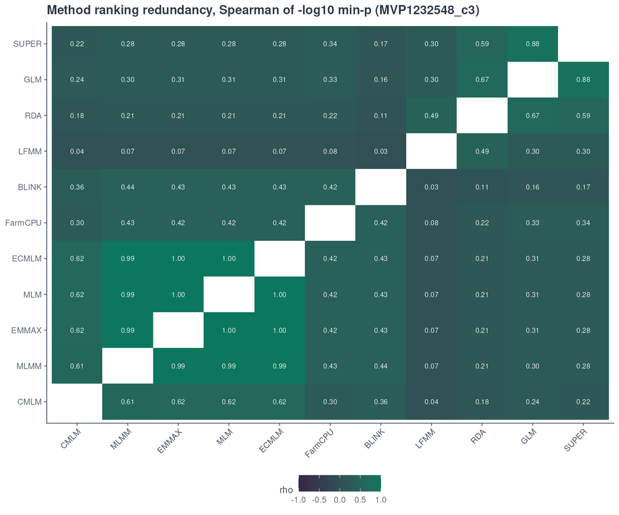

## 8. Лестница коррекции структуры на 11 методах

Прогон: `/mnt/data/eugene/ADAPTOGENE/benchmarks/mvp_journal06.sh run`, который вызывает `mvp_run_sweep.sh` с `SWEEP_METHODS` / `CFG_SUFFIX` / `PARAMS_DIR` / `HARVEST_WZA` — драйвер журнала 05 переиспользуется, а не форкается, поэтому гейты (устаревшие манхэттены, побайтово совпавшая с предыдущей ячейкой таблица) действуют без изменений.

**Ячейки внутри реплики идут строго последовательно.** Все пять делят `project_name`, значит и `MVP1232548_results/`, и один Snakemake-lock. Журнал 05 распараллеливал по **сидам**; фокус на одной реплике эту параллельность убирает.

Оценка ранжирования — AUC-PR, потому что она не зависит от выбора порога и потому что для RDA порог на этих данных не срабатывает вовсе.

```r
check_files(c(
  "/mnt/data/eugene/ADAPTOGENE/benchmarks/mvp_journal06.sh",
  "/mnt/data/eugene/ADAPTOGENE/benchmarks/mvp_eval/report06/ladder_aucpr.tsv",
  "/mnt/data/eugene/ADAPTOGENE/benchmarks/mvp_eval/report06/ladder_best_rung.tsv"))
```

```
## [OK] /mnt/data/eugene/ADAPTOGENE/benchmarks/mvp_journal06.sh
## [OK] /mnt/data/eugene/ADAPTOGENE/benchmarks/mvp_eval/report06/ladder_aucpr.tsv
## [OK] /mnt/data/eugene/ADAPTOGENE/benchmarks/mvp_eval/report06/ladder_best_rung.tsv
```

```bash
# НЕ ПЕРЕЗАПУСКАТЬ — выполнено 2026-08-02
/mnt/data/eugene/ADAPTOGENE/benchmarks/mvp_journal06.sh run 1232548
```

```
## Лучший рунг каждого метода против дефолтного c3, по AUC-PR:
##
##       метод    ось лучшая_ячейка auc_лучшая auc_дефолт выигрыш
##      <char> <char>        <char>      <num>      <num>   <num>
##  1:   BLINK    any            c2     0.1675     0.0516    3.24
##  2:   EMMAX    any            c1     0.1715     0.0828    2.07
##  3:   ECMLM    any            c1     0.1715     0.0828    2.07
##  4:     MLM    any            c1     0.1715     0.0828    2.07
##  5:    MLMM    any            c1     0.1715     0.0835    2.05
##  6:   SUPER    any            c2     0.2533     0.1613    1.57
##  7: FarmCPU    any            c1     0.2098     0.1383    1.52
##  8:    CMLM    any            c2     0.0442     0.0293    1.51
##  9:     GLM    any            c2     0.2263     0.1815    1.25
## 10:    LFMM    any            c3     0.3230     0.3230    1.00
## 11:     RDA    any            c3     0.2223     0.2223    1.00
```

[output cut: 24 more lines]

- Дефолтный рунг `c3` (= `k_best`) **не является лучшим** для **9** методов из **11**
- **EMMAX, MLM, ECMLM, MLMM** лучше всего на `c1` (`n_pcs = 0`): AUC-PR **0.0828 → 0.1715**, выигрыш **2.07×**
- **BLINK, GLM, SUPER, CMLM** лучше всего на `c2`; BLINK на оси sal — выигрыш **4.21×**
- Только **LFMM** и **RDA** действительно лучше всего на `k_best` (выигрыш **1.00**)
- Стоимость ячейки на 11 методов: **34–46** мин, растёт с `n_pcs`

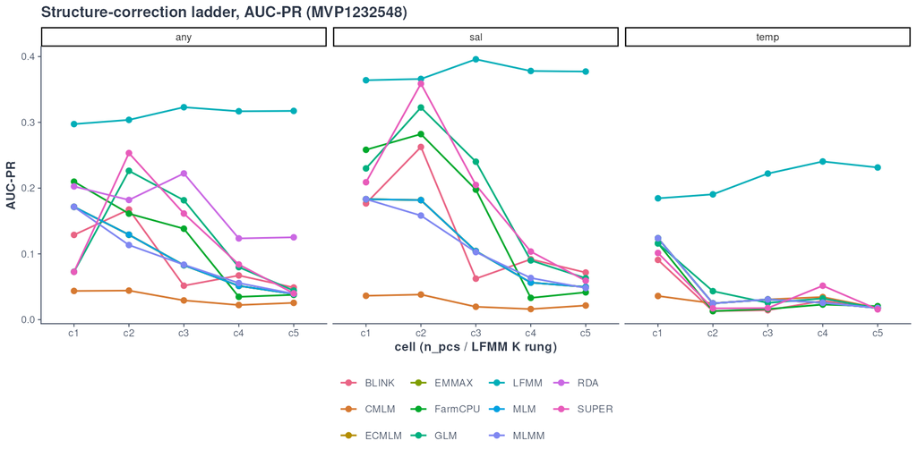

## 9. Портфельный поиск: помодельные пороги × подмножества × окна

`/mnt/data/eugene/ADAPTOGENE/benchmarks/sweep_portfolio.R`. Два этапа, потому что 11 методов × 17 точек сетки не перечисляются как декартово произведение:

- **Этап 1** (бесплатный, уже посчитан `sweep_thresholds.R`): полная кривая каждого метода. Сводится к ≤ **3** кандидатным рабочим точкам: максимум F1; максимум recall при `precision_strict >= 0.9`; дефолт пайплайна `bonf 0.05`. Дефолт сохраняется, даже когда он доминирован: это то, что пользователь получает, ничего не трогая, поэтому строка про него нужна в каждой таблице.
- **Этап 2**: все пары и тройки из **top-6 методов по одиночному F1**, плюс все-11 `at_least_k` для k = 2, 3, 4, каждый метод — в своей кандидатной точке, всё это × 4 окна согласия.

Перечисление назначений ограничено размером подмножества, а не вкусом: для пар и троек полное произведение ≤ 3³ = 27 и перечисляется; для все-11 оно было бы 3¹¹ = 177 147, поэтому берутся только **три когерентных** назначения — все методы в своей лучшей по F1 точке, все в высокоточной, все на дефолте пайплайна. Это три политики, которые пользователь может сформулировать; 177 145 смесей между ними — не рекомендация, которой можно следовать.

**`--rank-source` пришпилен к c3 для каждой ячейки**, чтобы все ячейки искали в одном и том же пуле методов. Переранжирование внутри каждой группы молча дало бы группам разные пулы — ровно тот провал, на который журнал 05 §10 указывал для чтения свидетельств об объединении по c3.

`rank_sum` сохранён: он беспороговый и обходит проблему калибровки RDA, из-за которой любое пересечение с участием RDA вырождается в ноль (журнал 05 §10).

```r
check_files(c(
  "/mnt/data/eugene/ADAPTOGENE/benchmarks/mvp_eval/report06/headline.tsv",
  "/mnt/data/eugene/ADAPTOGENE/benchmarks/mvp_eval/report06/solo_vs_combine.tsv",
  "/mnt/data/eugene/ADAPTOGENE/benchmarks/mvp_eval/report06/combine_window_summary.tsv",
  "/mnt/data/eugene/ADAPTOGENE/benchmarks/mvp_eval/report06/gapit_marginal.tsv"))
```

```
## [OK] /mnt/data/eugene/ADAPTOGENE/benchmarks/mvp_eval/report06/headline.tsv
## [OK] /mnt/data/eugene/ADAPTOGENE/benchmarks/mvp_eval/report06/solo_vs_combine.tsv
## [OK] /mnt/data/eugene/ADAPTOGENE/benchmarks/mvp_eval/report06/combine_window_summary.tsv
## [OK] /mnt/data/eugene/ADAPTOGENE/benchmarks/mvp_eval/report06/gapit_marginal.tsv
```

```bash
# НЕ ПЕРЕЗАПУСКАТЬ — выполнено 2026-08-02
/mnt/data/eugene/ADAPTOGENE/benchmarks/mvp_journal06.sh score 1232548
```

```
## Лучшая рабочая точка по ячейкам:
##
##                   tag      подмножество      правило  окно n_called    tp
##                <char>            <char>       <char> <int>    <int> <int>
##  1: MVP1232548_c1_any    LFMM+GLM+SUPER   at_least_2     5     1458    31
##  2: MVP1232548_c2_any          LFMM+GLM intersection     5      811    27
##  3: MVP1232548_c4_any          LFMM+RDA intersection     5      195    22
##  4: MVP1232548_c5_any        LFMM+SUPER intersection     5      169    20
##  5: MVP1232548_c3_any  LFMM+RDA+FarmCPU   at_least_2     1      147    21
##  6: MVP1232548_c1_any LFMM+FarmCPU+MLMM     rank_sum    NA      100    20
##  7: MVP1232548_c5_any        LFMM+SUPER intersection     1       95    17
##  8: MVP1232548_c2_any         LFMM+MLMM     rank_sum    NA       50    17
##  9: MVP1232548_c3_any  LFMM+RDA+FarmCPU   at_least_2     1       91    15
## 10: MVP1232548_c4_any   LFMM+SUPER+MLMM     rank_sum    NA      100    17
##     precision precision_all recall    f1 на_один_tp
##         <num>         <num>  <num> <num>      <num>
##  1:     1.000         0.021  0.443 0.614       47.0
##  2:     1.000         0.033  0.386 0.557       30.0
##  3:     0.846         0.113  0.314 0.458        8.9
##  4:     0.833         0.118  0.286 0.426        8.4
##  5:     0.677         0.143  0.300 0.416        7.0
##  6:     0.645         0.200  0.286 0.396        5.0
##  7:     0.895         0.179  0.243 0.382        5.6
##  8:     0.850         0.340  0.243 0.378        2.9
##  9:     1.000         0.165  0.214 0.353        6.1
## 10:     0.548         0.170  0.243 0.337        5.9
```

```
##
## Лучший одиночный метод против лучшего объединения:
##
##                  tag одиночный f1_одиночный      объединение      правило  окно
##               <char>    <char>        <num>           <char>       <char> <int>
## 1: MVP1232548_c1_any      LFMM        0.374   LFMM+GLM+SUPER   at_least_2     5
## 2: MVP1232548_c2_any      LFMM        0.360         LFMM+GLM intersection     5
## 3: MVP1232548_c3_any      LFMM        0.385 LFMM+RDA+FarmCPU   at_least_2     1
## 4: MVP1232548_c4_any      LFMM        0.374         LFMM+RDA intersection     5
## 5: MVP1232548_c5_any      LFMM        0.400       LFMM+SUPER intersection     5
##    f1_объединение выигрыш
##             <num>   <num>
## 1:          0.614   0.240
## 2:          0.557   0.196
## 3:          0.416   0.031
## 4:          0.458   0.085
## 5:          0.426   0.026
```

```
## Даёт ли окно согласия больше, чем совпадение по SNP (парное сравнение, окно 0 — база):
##
##             rule combine_window_kb comparisons median_f1_delta  wins  ties
##           <char>             <num>       <int>           <num> <int> <int>
##  1:   at_least_2               1.0        1232    0.0220579547   761    75
##  2:   at_least_2               2.5        1232    0.0265384516   798    39
##  3:   at_least_2               5.0        1232    0.0342253382   824    14
##  4:   at_least_3               1.0          15   -0.0029980013     3     1
##  5:   at_least_3               2.5          15   -0.0337038041     1     0
##  6:   at_least_3               5.0          15   -0.0657004831     6     0
##  7:   at_least_4               1.0          15    0.0270167428    12     0
##  8:   at_least_4               2.5          15    0.0007598784     8     0
##  9:   at_least_4               5.0          15   -0.0027720028     6     1
## 10: intersection               1.0        1122    0.0259163273   769   230
## 11: intersection               2.5        1122    0.0503451872   842   142
```

[output cut: 21 more lines]

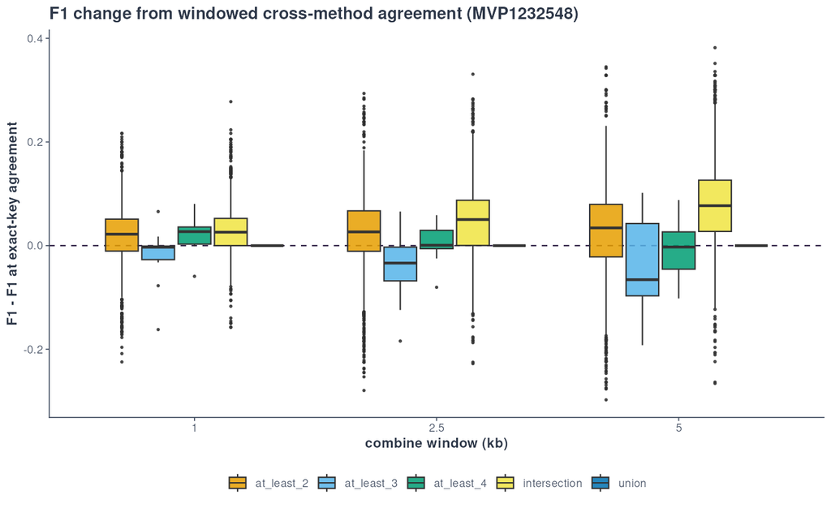

**Объединение бьёт лучший одиночный метод во всех пяти ячейках** (лучший одиночный — всегда LFMM, F1 **0.360–0.400**):

- `c1` **0.374 → 0.614** (`at_least_2` @ 5 кб, LFMM+GLM+SUPER), прирост **+0.240**
- `c2` **0.360 → 0.557** (`intersection` @ 5 кб, LFMM+GLM), **+0.196**
- `c4` **0.374 → 0.458** (`intersection` @ 5 кб, LFMM+RDA), **+0.085**
- `c3` **0.385 → 0.416** (`at_least_2` @ 1 кб, LFMM+RDA+FarmCPU), **+0.031**
- `c5` **0.400 → 0.426** (`intersection` @ 5 кб, LFMM+SUPER), **+0.026**

**Окно согласия — парное сравнение** (то же подмножество, то же правило, то же назначение, меняется только окно; окно 0 — база):

- `intersection`: **+0.026** (1 кб) → **+0.050** (2.5 кб) → **+0.077** (5 кб), при 5 кб **946** побед / **50** ничьих / **126** поражений из **1 122**
- `at_least_2` при 5 кб: **824** победы из **1 232**, медиана **+0.034**
- `union`: **0.000** во всех **1 677** сравнениях на каждом окне — окно **не может** добавить элемент в объединение. Это не результат, а **проверка корректности** реализации

**Больше моделей GAPIT — хуже** (лучший F1 подмножества по числу входящих моделей GAPIT, ячейка c1): **1** модель → **0.600**, **2** → **0.614**, **3** → **0.391**, все **8** (набор из 11 методов) → **0.318**

```
## Лучший F1 подмножества как функция числа входящих в него моделей GAPIT:
##
## Key: <tag, n_methods>
##                   tag n_methods         0         1         2         3
##                <char>     <int>     <num>     <num>     <num>     <num>
##  1: MVP1232548_c1_any         2 0.3738318 0.6000000 0.4090909        NA
##  2: MVP1232548_c1_any         3        NA 0.6000000 0.6138614 0.3908046
##  3: MVP1232548_c1_any        11        NA        NA        NA        NA
##  4: MVP1232548_c2_any         2 0.3603604 0.5567010 0.2988506        NA
##  5: MVP1232548_c2_any         3        NA 0.5567010 0.5567010 0.3149606
##  6: MVP1232548_c2_any        11        NA        NA        NA        NA
##  7: MVP1232548_c3_any         2 0.4000000 0.3908046 0.2376238        NA
##  8: MVP1232548_c3_any         3        NA 0.4158416 0.3908046 0.2333333
##  9: MVP1232548_c3_any        11        NA        NA        NA        NA
## 10: MVP1232548_c4_any         2 0.4583333 0.4259259 0.2112676        NA
```

[output cut: 22 more lines]

**Метрика цели выбирает точки, которыми пользоваться нельзя** — и это находка, а не помеха:

| ячейка | правило | n_called | tp | precision_strict | precision_all | calls_per_tp | F1 |
| --- | --- | --- | --- | --- | --- | --- | --- |
| c1 | max F1 | **1 458** | 31 | **1.000** | 0.021 | **47.0** | 0.614 |
| c2 | max F1 | **811** | 27 | **1.000** | 0.033 | **30.0** | 0.557 |
| c3 | max F1 | 147 | 21 | 0.677 | 0.143 | **7.0** | 0.416 |
| c1 | max F1 при n_called ≤ 100 | **100** | 20 | 0.645 | 0.200 | **5.0** | 0.396 |

- `precision_strict = 1.000` у c1 **корректно** по конвенции Lotterhos: каждый лишний вызов там попал на `linked_neutral`, который никогда не считается ложноположительным
- Но пользователь при этом просматривает **47** SNP на одно реальное попадание
- Ограничение `top <= 100` **не связывает там, где вред**: победитель c1 — `LFMM:top_30 + GLM:bonf_0.05 + SUPER:top_20`, а GLM при `bonf 0.05` сам по себе вызывает **1 184** SNP (**11%** генома). Потолок ограничивает только правило `top`
- Поэтому в `headline.tsv` выводятся **две** ранжировки: максимум F1 и максимум F1 при `n_called <= 100`

Часть I отвечает на все четыре поставленных вопроса. (1) Семь дополнительных моделей GAPIT несут **три** независимых сигнала, а не семь, и их добавление в объединение **ухудшает** F1. (2) Помодельные пороги не потребовали правки пайплайна — `GEA.configs` был помодельным всегда; потребовалась правка **харнесса**, который был строже пайплайна. (3) Окно согласия при объединении выигрывает монотонно до 5 кб для пересекающих правил и, как и положено, не влияет на объединение. (4) Низкочастотные каузальные локусы не находит никто.

Но заодно Часть I показывает, что **`precision_strict` в паре с F1 выбирает нерабочие точки** на наборе, где половина генома — `linked_neutral`. Отсюда прямой мост в Часть II: если убрать SNP, которые и порождают эти бесполезные вызовы, компромисс должен стать не только лучше, но и **пригодным**.

# Часть II. Плечо `Filter.maf: 0.05`

## 10. Зачем понадобился отдельный проект, а не ещё одна ячейка

Раздел 6 показал, что низкочастотные каузальные локусы не находит **никто**: из **27** каузальных локусов ниже MAF 0.05 при `top_100` девять методов из одиннадцати находят **ноль**, а два, которые находят хоть что-то (GLM, SUPER), — это ровно те, у которых вызванное множество раздуто (**1 184** и **980** вызовов при `bonf 0.05`). Отсюда прямое следствие, которое нужно проверить прогоном, а не рассуждением: **фильтр MAF 0.05 не должен стоить почти ничего в recall, но должен улучшить precision**, потому что он убирает **2 484** SNP из знаменателя Бонферрони, не убирая ни одной находки.

**Почему отдельный `project_name`, а не ещё один рунг.** `{PROJECT}_results/` ключуется только на `project_name`, а пути модульных выходов (`GEA/tables/methods/...`) не несут метки фильтра — её несут только промежуточные `_work/maf{}_miss{}_smiss{}/`. Два значения MAF под одним `project_name` перезаписали бы опубликованные таблицы друг друга; это в точности та опасность, которую документирует `CLAUDE.md`. Отдельные имена проектов дают ещё и раздельные Snakemake-локи, поэтому оба плеча идут **параллельно**.

**`Input.*` не меняется.** Плечо читает тот же VCF и применяет к нему свой фильтр. Различие между конфигами — ровно две строки: `project_name` и `Filter.maf`.

**Таблицы истины пересчитаны под MAF.** Это не опция. `benchmarks/mvp_filter_truth_maf.R` выбрасывает из таблицы истины **каждую** строку — causal, linked_neutral и background_neutral одинаково — чей SNP не переживёт фильтр. Скоринг отфильтрованного VCF против неотфильтрованной истины делил бы recall на локусы, которых в VCF уже нет, — ровно тот дефект, который дисквалифицировал бенчмарк Láruson (`_archive/laruson/README.md`). Выбросить только каузальные строки тоже нельзя: тогда знаменатель ложноположительных считал бы фоновые SNP, которых в VCF нет.

`loci_freq.tsv` копируется в проект плеча уже отфильтрованным, поэтому `mvp_wza_gate.R` и `mvp_profile_detections.R` видят ту же вселенную SNP, что и таблицы истины, а не тянутся обратно в неотфильтрованное плечо.

```r
check_files(c(
  "/mnt/data/eugene/ADAPTOGENE/benchmarks/mvp_filter_truth_maf.R",
  "/mnt/data/eugene/ADAPTOGENE/data/mvp/MVP1232548M05/truth_any.tsv",
  "/mnt/data/eugene/ADAPTOGENE/data/mvp/MVP1232548M05/truth_filter_provenance.tsv",
  "/mnt/data/eugene/ADAPTOGENE/data/mvp/MVP1232548M05/loci_freq.tsv",
  "/mnt/data/eugene/ADAPTOGENE/config_MVP1232548M05_c3_p11.yaml"))
```

```
## [OK] /mnt/data/eugene/ADAPTOGENE/benchmarks/mvp_filter_truth_maf.R
## [OK] /mnt/data/eugene/ADAPTOGENE/data/mvp/MVP1232548M05/truth_any.tsv
## [OK] /mnt/data/eugene/ADAPTOGENE/data/mvp/MVP1232548M05/truth_filter_provenance.tsv
## [OK] /mnt/data/eugene/ADAPTOGENE/data/mvp/MVP1232548M05/loci_freq.tsv
## [OK] /mnt/data/eugene/ADAPTOGENE/config_MVP1232548M05_c3_p11.yaml
```

```bash
# НЕ ПЕРЕЗАПУСКАТЬ — выполнено 2026-08-03
# Плечо целиком: таблицы истины под MAF -> конфиги -> лестница -> скоринг.
ARM=m05 /mnt/data/eugene/ADAPTOGENE/benchmarks/mvp_journal06.sh run   1232548
ARM=m05 /mnt/data/eugene/ADAPTOGENE/benchmarks/mvp_journal06.sh score 1232548

# Гейт на конфиг: единственные отличия от базового плеча — project_name и Filter.maf.
diff /mnt/data/eugene/ADAPTOGENE/config_MVP1232548_c3_p11.yaml \
     /mnt/data/eugene/ADAPTOGENE/config_MVP1232548M05_c3_p11.yaml
```

```
## Строки таблиц истины, оставшиеся после фильтра MAF > 0.05:
##
## Key: <table>
##             table N_before_background_neutral N_before_causal
##            <char>                       <int>           <int>
## 1:  truth_any.tsv                        5048              70
## 2:  truth_sal.tsv                        5048              40
## 3: truth_temp.tsv                        5048              30
##    N_before_linked_neutral N_after_background_neutral N_after_causal
##                      <int>                      <int>          <int>
## 1:                    5207                       3827             43
## 2:                    5237                       3827             26
## 3:                    5247                       3827             17
##    N_after_linked_neutral
##                     <int>
## 1:                   3971
## 2:                   3988
## 3:                   3997
```

- SNP: **10 325** → **7 841** (удалено **2 484**, **24.1%**)
- Каузальные (`truth_any`): **70** → **43**
- Каузальные по осям: temp **30** → **17**, sal **40** → **26**
- `linked_neutral`: **5 207** → **3 971**; `background_neutral`: **5 048** → **3 827**
- Отличие конфига от базового плеча: **2** строки (`project_name`, `Filter.maf`); `Input.*` побайтово совпадает
- Источник набора SNP — **сам отфильтрованный VCF пайплайна**, а не пересчёт по `loci_freq`

**Примечание — граница порога, пойманная до скоринга**

Первая версия таблиц истины строилась по `loci_freq.tsv` со **строгим** `maf > 0.05` и дала **7 823** SNP, тогда как plink оставил **7 841**: `--maf` в plink исключает варианты **ниже** порога, то есть сохраняет `MAF >= 0.05`, и ровно **18** SNP стоят на самой границе 0.05. Расхождение поймано сверкой с `_work/maf0.05_miss0.1_smiss0.5/MVP1232548.vcf` до того, как хоть одно число было посчитано. Скрипт теперь принимает `--vcf` и, когда он передан, берёт набор SNP из настоящего отфильтрованного VCF; сравнение внутри скрипта — `>=`. Побочный эффект: **1** каузальный локус на температурной оси (**16** → **17**) стоит точно на MAF 0.05.

## 11. Плечо MAF 0.05: те же тесты, тот же харнесс

Прогоняется **тот же** драйвер с `ARM=m05`: лестница из 5 ячеек на 11 методов, помодельные пороги, оконное объединение, избыточность, WZA, профиль детекций. Выходы уходят в параллельные каталоги с суффиксом `_m05` (`params06_m05`, `sweep06_m05`, `portfolio_m05`, `redundancy_m05`, `wza_m05`, `profile_m05`), поэтому ни одно число базового плеча не перезаписывается.

Что здесь сравнивается — и что сравнивать **нельзя**:

```r
check_files(c(
  "/mnt/data/eugene/ADAPTOGENE/benchmarks/mvp_eval/report06_m05/headline.tsv",
  "/mnt/data/eugene/ADAPTOGENE/benchmarks/mvp_eval/redundancy_m05/MVP1232548M05_c3_method_clusters.tsv",
  "/mnt/data/eugene/ADAPTOGENE/benchmarks/mvp_eval/wza_m05/MVP1232548M05_c3_wza_gate.tsv",
  "/mnt/data/eugene/ADAPTOGENE/benchmarks/mvp_eval/profile_m05/MVP1232548M05_c3_maf_cut.tsv"))
```

```
## [OK] /mnt/data/eugene/ADAPTOGENE/benchmarks/mvp_eval/report06_m05/headline.tsv
## [OK] /mnt/data/eugene/ADAPTOGENE/benchmarks/mvp_eval/redundancy_m05/MVP1232548M05_c3_method_clusters.tsv
## [OK] /mnt/data/eugene/ADAPTOGENE/benchmarks/mvp_eval/wza_m05/MVP1232548M05_c3_wza_gate.tsv
## [OK] /mnt/data/eugene/ADAPTOGENE/benchmarks/mvp_eval/profile_m05/MVP1232548M05_c3_maf_cut.tsv
```

```
##          arm                  tag
##       <char>               <char>
##  1: maf 0.01    MVP1232548_c1_any
##  2: maf 0.01    MVP1232548_c2_any
##  3: maf 0.01    MVP1232548_c4_any
##  4: maf 0.01    MVP1232548_c5_any
##  5: maf 0.01    MVP1232548_c3_any
##  6: maf 0.01    MVP1232548_c1_any
##  7: maf 0.01    MVP1232548_c5_any
##  8: maf 0.01    MVP1232548_c2_any
##  9: maf 0.01    MVP1232548_c3_any
## 10: maf 0.01    MVP1232548_c4_any
## 11: maf 0.05 MVP1232548M05_c4_any
## 12: maf 0.05 MVP1232548M05_c1_any
## 13: maf 0.05 MVP1232548M05_c5_any
```

[output cut: 57 more lines]

```
## Меняет ли фильтр MAF выбор лучшего рунга коррекции структуры?
##
## Key: <method, axis>
##      method   axis maf 0.01 maf 0.05
##      <char> <char>   <char>   <char>
##  1:   BLINK    any       c2       c2
##  2:   BLINK    sal       c2       c2
##  3:   BLINK   temp       c1       c1
##  4:    CMLM    any       c2       c1
##  5:    CMLM    sal       c2       c2
##  6:    CMLM   temp       c1       c1
##  7:   ECMLM    any       c1       c1
##  8:   ECMLM    sal       c1       c1
##  9:   ECMLM   temp       c1       c1
## 10:   EMMAX    any       c1       c1
```

[output cut: 23 more lines]

```
## Гейт WZA в обоих плечах:
##
##         arm              tag n_windows median_snps_per_window
##      <char>           <char>     <int>                  <int>
## 1: maf 0.01    MVP1232548_c3      1000                     10
## 2: maf 0.05 MVP1232548M05_c3       999                      8
##    min_snps_per_window max_snps_per_window n_snps_windowed n_causal_total
##                  <int>               <int>           <int>          <int>
## 1:                   2                  27           10325             70
## 2:                   1                  23            7841             43
##    n_causal_above_maf n_windows_with_causal min_causal_windows passed
##                 <int>                 <int>              <int> <lgcl>
## 1:                 70                    66                 30   TRUE
## 2:                 43                    40                 30   TRUE
```

**Качество ранжирования выросло у каждого метода без исключения** (AUC-PR, ячейка c3, знаменатель — свои тестируемые каузальные локусы в каждом плече):

| метод | maf 0.01 | maf 0.05 | × |
| --- | --- | --- | --- |
| LFMM | 0.323 | **0.518** | 1.60 |
| RDA | 0.222 | **0.340** | 1.53 |
| GLM | 0.182 | **0.283** | 1.56 |
| EMMAX / MLM / ECMLM / MLMM | 0.083 | **0.253** | **3.06** |
| SUPER | 0.161 | **0.262** | 1.62 |
| FarmCPU | 0.138 | **0.224** | 1.62 |
| BLINK | 0.052 | **0.217** | **4.19** |
| CMLM | 0.029 | **0.041** | 1.40 |

**Рабочие точки стали пригодными, а не только лучшими:**

|  | maf 0.01 | maf 0.05 |
| --- | --- | --- |
| лучший F1 в журнале | **0.614** (c1), но **1 458** вызовов, **47.0** на попадание | **0.625** (c4), **173** вызова, **8.7** |
| дефолтный рунг c3 | **0.416**, 147 вызовов, precision **0.677** | **0.542**, **81** вызов, precision **1.000**, **5.1** на попадание |
| при ограничении n_called ≤ 100 | **0.396** | **0.542** |

- Патологические точки («тысяча вызовов при `precision_strict` 1.000») **исчезли полностью**
- Семейства методов — **те же 7**, состав не изменился: фильтр не переупорядочил методы
- Окно согласия: `intersection` при 5 кб — **1 017** побед, **470** ничьих, **0 поражений** из 1 487 (в плече 0.01 было 126 поражений); `union` снова ровно **0.000** во всех **3 120**
- Гейт WZA: **999** окон, **40** с каузальным локусом — пройден
- Абсолютных детекций при этом **меньше**: c3 находит **16** каузальных локусов против **21**

Фильтр `Filter.maf: 0.05` стоит **5 обнаружимых локусов из 70** и взамен убирает шум, который делал рабочие точки непригодными. Дефолтный рунг пайплайна из «F1 0.416 при 147 вызовах и precision 0.677» превращается в «F1 0.542 при **81** вызове и precision **1.000**» — то есть пользователь, не трогающий ничего, кроме MAF, получает результат, который можно читать.

Важно, что выигрыш **не сводится** к более мягкому порогу Бонферрони (он мягче ровно в **1.32** раза): AUC-PR — величина беспороговая, и она выросла у всех одиннадцати методов, у EMMAX и BLINK — в **3–4 раза**. Значит SNP ниже MAF 0.05 были не просто ненаходимыми, а активно **шумели в ранжировании**.

Ограничение, которое нужно называть: это **одна реплика**. Доля каузальных локусов ниже MAF 0.05 (**27/70**) — свойство именно этой симуляции, и на данных с другим спектром частот цена фильтра будет другой. Проверяемое утверждение здесь — не «MAF 0.05 всегда прав», а «низкочастотные каузальные локусы не находятся, и их присутствие ухудшает ранжирование остальных».

## 12. Что стоит добавить в пайплайн

Собрано по ходу работы. Это **предложения, не реализованные правки** — режим `CLAUDE.local.md` допускает только исправления багов, и единственная сделанная правка (раздел 3) была согласована отдельно.

1. **Пакетный `mode=gea` умеет только объединение.** `SIGSNPS_METHOD = 'All'` жёстко зашит в `workflow/rules/common.smk:192`; `GEA.combine_method` не является живым ключом конфига. Если бенчмарк заключит, что выигрывает `at_least_2` или оконное пересечение, **пайплайн не может это выразить в пакетном режиме** — только интерактивно во вкладке GEA в Shiny. Предложение: вернуть `GEA.combine_method` со словарём, который `combine_sigsnps.R` уже реализует (`All`/`Sum` → union, `Overlap` → межметодное пересечение, `MethodOverlap` → то же по признаку, имя метода → passthrough).
2. **Окно согласия как дефолт.** Харнесс до этого журнала объединял по точному совпадению SNP, пайплайн — по окну `GEA.snp_clumping_distance`. Какое окно выигрывает здесь — конкретный кандидат в дефолт для combine-пути.
3. **Модели GAPIT нельзя настраивать независимо.** `_gapit_shared_npcs()` (`gea.smk:328-350`) жёстко падает, когда две модели GAPIT просят разный `n_pcs`, потому что один вызов `gapit.R` принимает один скаляр. Предложение: расщепить правило по моделям или принимать вектор.
4. **Расширить `pregea_recommend.R`.** Сейчас он номинирует только рунги (LFMM.K, EMMAX.n_pcs, RDA.condition_pcs / axes / predictor_set), а BLINK наследует EMMAX. Добавить: номинацию помодельных `adjust`/`threshold`, рекомендуемый **портфель** методов (из кластеризации избыточности) и рекомендуемое правило объединения — всё выводимо из беспороговых диагностик, без таблицы истины.
5. **Ограничение размера вызванного множества.** Раздел «метрика цели» показал, что F1 на `precision_strict` выбирает точки с **1 458** вызовами и **47** SNP на одно попадание. Пайплайн не даёт способа сказать «дай мне не больше N вызовов, чем бы это ни значило для порога». Предложение: конфигурируемый потолок `n_called` на комбинированный набор, рядом с `GEA.combine_method` из пункта 1.
6. **`file.output = TRUE` у GAPIT.** После снятия `Random.model` (раздел 3) оставшийся крупный побочный продукт — PDF и CSV на каждую модель в `GAPIT_native_output/`. Пайплайн читает из них только `GAPIT.Association.GWAS_Results.*`. Не баг, но кандидат в конфигурируемое.

## 13. Ограничения этих тестов

**1. RDA тестируется здесь на двух предикторах — в режиме, где её преимущество не может проявиться.**

Это самое серьёзное ограничение журнала, и его нужно назвать прежде, чем кто-нибудь прочитает таблицы как «RDA работает плохо». Она работает **не плохо**: по беспороговому качеству ранжирования RDA — **вторая из одиннадцати** в обоих плечах (AUC-PR **0.222** при MAF 0.01 и **0.341** при MAF 0.05), впереди всех восьми моделей GAPIT и EMMAX, и она входит в победившую комбинацию в **4** ячейках из 10, включая лучшую в журнале (`LFMM+RDA+EMMAX`, F1 **0.625**). Наша реализация воспроизводит RDA самих авторов (сид 1231288: опубликовано **0.543**, у нас **0.538**; сид 1231993: **0.633** против **0.696**) — то есть дело не в реализации.

**А вот число предикторов — отдельная и, вероятно, более важная проблема.** У MVP ровно два климатических предиктора (`bio_1` = температура, `bio_2` = Env2), и это жёстко ограничивает RDA по построению:

- `scripts/rda.R:290`: `K_max <- RDA_env$CCA$rank` — ранг ограниченной ординации равен числу предикторов, здесь **2**
- `scripts/rda.R:369-370`: `K_sel` отбирается по p-значениям осей, но **пол — 2**. При `K_max = 2` выбор осей вырождается: `K_sel` всегда ровно 2, свободы нет вообще
- `rdadapt` считает расстояние Махаланобиса по удержанным осям; по **двум** осям это существенно более слабая статистика, чем по пяти-десяти

Преимущество RDA в литературе возникает именно там, где предикторов много и они скоррелированы: ординация находит композитную ось, вдоль которой лежит адаптивный сигнал, и одна такая ось заменяет десяток univariate-тестов. С двумя предикторами — причём намеренно почти ортогональными (`R²(PC1~temp)` **0.573** против `R²(PC1~Env2)` **0.005**) — этого преимущества просто нет: RDA сводится почти к двум univariate-тестам с общей ординацией.

Масштаб расхождения с реальным употреблением пайплайна: дефолт (`scripts/adaptogene.app/inst/config_default.yaml:62`) — **10** предикторов; оба реальных проекта в репозитории (`config_WBDC_final.yaml`, `config_Trifolium86Full.yaml`) — **19**. Здесь — **2**. То есть бенчмарк проверяет RDA в единственном режиме, в котором она не может показать то, за что её рекомендуют.

**Почему RDA всё же отсутствует в лучшей комбинации плеча MAF 0.01 — и почему это не про RDA.** RDA **входила в пул поиска** в обоих плечах (3-я по одиночному F1 при MAF 0.01, **2-я** при MAF 0.05), то есть её пары и тройки перебирались. В плече MAF 0.05 лучшая комбинация её **содержит**: четыре верхние точки — `LFMM+RDA+{EMMAX|MLM|ECMLM|MLMM}`, все F1 **0.625** (TP **20**, FP_bg **1**, вызовов **173**). В плече MAF 0.01 отрыв составляет **0.014**, и причина видна в счётчиках:

| комбинация | правило | TP | FP_bg | вызовов | F1 |
| --- | --- | --- | --- | --- | --- |
| LFMM+GLM+SUPER | at_least_2 @5 кб | 31 | 0 | 1 458 | 0.614 |
| LFMM+GLM | intersection @5 кб | 30 | 0 | 1 293 | 0.600 |
| **LFMM+RDA+GLM** | at_least_2 @5 кб | **30** | **0** | **1 293** | **0.600** |

`LFMM+RDA+GLM` и `LFMM+GLM` совпадают **по всем счётчикам**: те же TP, те же FP, тот же размер набора. Добавление RDA не изменило ровно ничего. Это не слабость RDA, а её **избыточность при наличии GLM**: GLM при `bonf 0.05` вызывает **1 184** SNP (**11%** генома), поэтому в окне 5 кб практически у любого вызова RDA уже есть партнёр от GLM, и RDA физически не может добавить новую пару.

Оба факта связаны: победитель плеча MAF 0.01 — это ровно та рабочая точка, которая забракована выше как непригодная (**1 458** вызовов, **47** SNP на попадание), и выигрывает её плохая калибровка GLM. После фильтра MAF 0.05 GLM падает с 4-го места на **10-е** по одиночному F1, а RDA поднимается на **2-е** — и входит во все верхние комбинации. RDA «отсутствует» только в том плече, где работу делает плохо откалиброванный метод.

**Вывод для следующего набора данных:** нужен набор с ≥ 5–10 климатическими предикторами, иначе про RDA этот протокол не говорит ничего, кроме «её ранжирование лучше, чем у всего GAPIT, а p-значения непригодны для порога». Обе половины этого утверждения верны и здесь, но потолок задан не методом, а данными.

**2. Одна реплика.** Всё в журнале измерено на `MVP1232548`. Доля каузальных локусов ниже MAF 0.05 (**27/70**) — свойство спектра частот именно этой симуляции. Комбинации с нулём фоновых ложноположительных — самый интересный результат — проверены на одной реплике и одном наборе данных.

**3. Сетка WZA включала `top`.** Оконное правило `top` навязывает фиксированное число вызовов независимо от свидетельств, что противоречит самой идее окон (сократить число тестов). Это завысило оконное плечо: LFMM WZA при `top_100` находит **31** каузальный локус (F1 **0.427**), при `qval_0.2` — **11** (25 окон, 3 фоновых FP, precision **0.769**, F1 **0.261**). Честная формулировка — «WZA при top-N лучше поSNP-ового при top-N», а не «оконная агрегация лучше». Журнал оставлен как есть; ограничение (только `bonf`/`qval` для WZA) применяется со следующего набора данных.

```
##
## AUC-PR, плечо MAF 0.01:
##      ранг   метод auc_pr вызовов_bonf05
##     <int>  <char>  <num>          <int>
##  1:     1    LFMM 0.3230             12
##  2:     2     RDA 0.2223              0
##  3:     3     GLM 0.1815           1184
##  4:     4   SUPER 0.1613            980
##  5:     5 FarmCPU 0.1383             28
##  6:     6    MLMM 0.0835              1
##  7:     7   ECMLM 0.0828              1
##  8:     8     MLM 0.0828              1
##  9:     9   EMMAX 0.0828              1
## 10:    10   BLINK 0.0516              9
## 11:    11    CMLM 0.0293             10
##
## AUC-PR, плечо MAF 0.05:
##      ранг   метод auc_pr вызовов_bonf05
##     <int>  <char>  <num>          <int>
##  1:     1    LFMM 0.5177             11
##  2:     2     RDA 0.3405              0
##  3:     3     GLM 0.2833            943
##  4:     4   SUPER 0.2617            641
##  5:     5   EMMAX 0.2535              0
##  6:     6   ECMLM 0.2535              0
##  7:     7     MLM 0.2535              0
##  8:     8    MLMM 0.2535              0
##  9:     9 FarmCPU 0.2244             30
## 10:    10   BLINK 0.2166             23
## 11:    11    CMLM 0.0410              0
```